# Session_4-AnalysingData

# 5 From Linear to Mixed models. Why random effects matter

Let’s generate a new dataframe that we will use later on for our mixed models

```r
set.seed(666)
#we create 6 subjects
subjects <- paste0('S', 1:6)
#here we ad repetitions within speakers
subjects <- rep(subjects, each = 20)
items <- paste0('Item', 1:20)
#below repeates
items <- rep(items, 6)
#below is to generate random numbers that are log values
logFreq <- round(rexp(20)*5,2)
#below we are repeating the logFreq 6 times to fit with the number of speakers and items
logFreq <- rep(logFreq,6)
xdf <- data.frame(subjects, items, logFreq)
#below removes the individual variables we had created because they are already in the dataframe
rm(subjects,items,logFreq)
xdf$Intercept <- 300
submeans <- rep(rnorm(6,sd = 40),20)
#sort make the means for each subject is the same...
submeans <- sort(submeans)
xdf$submeans <- submeans
#we create the same thing for items... we allow the items mean to vary between words...
itsmeans <- rep(rnorm(20,sd=20),6)
xdf$itsmeans <- itsmeans
xdf$error <- rnorm(120,sd=20)
#here we create an effect column,
#here for each logFreq, we have a decrease of -5 of that particular logFreq
xdf$effect <- -5*xdf$logFreq
xdf$dur <- xdf$Intercept +xdf$submeans +xdf$itsmeans +xdf$error + xdf$effect
#below is to subset the data and get only a few columns.. the -c(4:8) removes the columns 4 to 8..
xreal <- xdf[,-c(4:8)]
head(xreal)
```

|  | subjects | items | logFreq | dur |
| --- | --- | --- | --- | --- |
| 1 | S1 | Item1 | 2.74 | 312.4086 |
| 2 | S1 | Item2 | 9.82 | 236.5816 |
| 3 | S1 | Item3 | 0.70 | 364.6832 |
| 4 | S1 | Item4 | 0.05 | 243.3778 |
| 5 | S1 | Item5 | 2.76 | 302.8896 |
| 6 | S1 | Item6 | 17.57 | 196.5565 |

```r
rm(xdf,submeans,itsmeans)
```

## 5.1 Correlations and plots

Let’s start by doing a correlation test and plotting the data. Our results show that there is a negative correlation between duration and LogFrequency, and the plot shows this decrease.

```r
cor5 <- xreal %>%
  correlation()
summary(cor5)
```

|  | logFreq |
| --- | --- |
| logFreq |  |
| dur | -0.54*** |

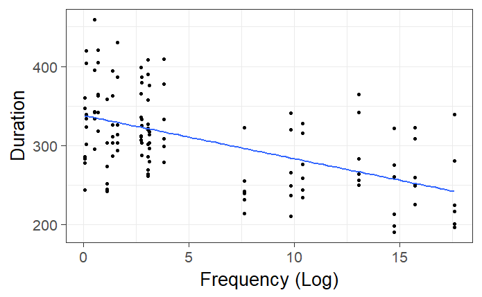

```r
ggplot.xreal <- ggplot(xreal,aes(x=logFreq,y=dur))+
                geom_point()+theme_bw(base_size = 20)+
                labs(y = "Duration", x = "Frequency (Log)")+
                geom_smooth(method = lm, se=F)
ggplot.xreal
```

## 5.2 Linear model

Let’s run a simple linear model on the data. As we can see below, thereare some issues with the “simple” linear model: we had set our SD for subjects to be 40, but this was picked up as 120 (see histogram of residuals). The QQ Plot is not “normal”.

```r
mdl.lm.xreal <- lm(dur~logFreq, data=xreal)
summary(mdl.lm.xreal)
```

```
Call:
lm(formula = dur ~ logFreq, data = xreal)

Residuals:
    Min      1Q  Median      3Q     Max
-94.322 -35.465  -4.364  33.020 123.955

Coefficients:
            Estimate Std. Error t value Pr(>|t|)
(Intercept) 337.9730     6.2494  54.081  < 2e-16 ***
logFreq      -5.4601     0.7846  -6.959 2.06e-10 ***
---
Signif. codes:  0 ‘***’ 0.001 ‘**’ 0.01 ‘*’ 0.05 ‘.’ 0.1 ‘ ’ 1

Residual standard error: 48.29 on 118 degrees of freedom
Multiple R-squared:  0.291, Adjusted R-squared:  0.285
F-statistic: 48.43 on 1 and 118 DF,  p-value: 2.057e-10
```

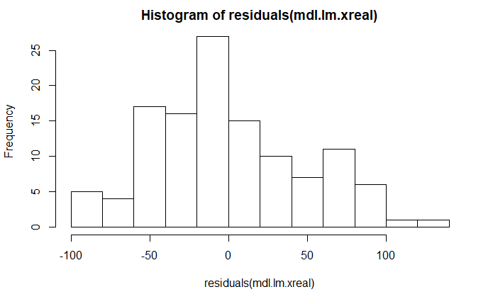

```r
hist(residuals(mdl.lm.xreal))
```

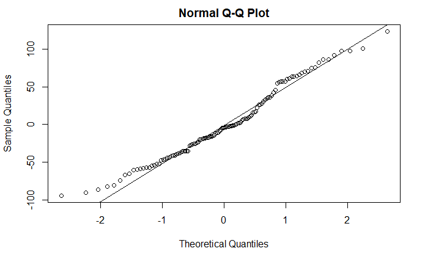

```r
qqnorm(residuals(mdl.lm.xreal)); qqline(residuals(mdl.lm.xreal))
```

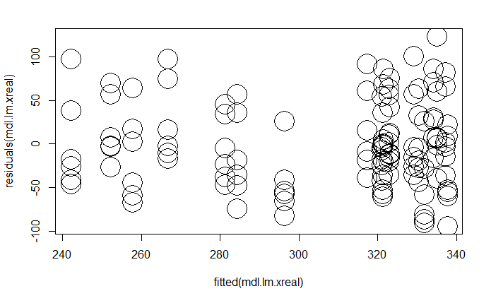

```r
plot(fitted(mdl.lm.xreal),residuals(mdl.lm.xreal), cex = 4)
```

## 5.3 Linear Mixed Model

Our Linear Mixed effects Model will take into account the random effects we added and also our model specifications. We use a Maximum Likelihood estimate (REML=FALSE) as this is what we will use for model comparison. The Linear Mixed Model is reflecting our model specifications The SD of our subjects is picked up correctly. The model results are “almost” the same as our linear model above. The coefficient for the “Intercept” is at 337.973 and the coefficient for LogFrequency is at -5.460. This indicates that for each unit of increase in the LogFrequency, there is a decrease by 5.460 (ms).

```r
mdl.lmer.xreal <- lmer(dur~logFreq+(1|subjects)+(1|items), data=xreal,REML=FALSE)
summary(mdl.lmer.xreal)
```

```
Linear mixed model fit by maximum likelihood  ['lmerMod']
Formula: dur ~ logFreq + (1 | subjects) + (1 | items)
   Data: xreal

     AIC      BIC   logLik deviance df.resid
  1105.8   1119.8   -547.9   1095.8      115

Scaled residuals:
     Min       1Q   Median       3Q      Max
-2.06735 -0.60675  0.07184  0.61122  2.39854

Random effects:
 Groups   Name        Variance Std.Dev.
 items    (Intercept)  589.8   24.29
 subjects (Intercept) 1471.7   38.36
 Residual              284.0   16.85
Number of obs: 120, groups:  items, 20; subjects, 6

Fixed effects:
            Estimate Std. Error t value
(Intercept)  337.973     17.587  19.217
logFreq       -5.460      1.004  -5.436

Correlation of Fixed Effects:
        (Intr)
logFreq -0.322
```

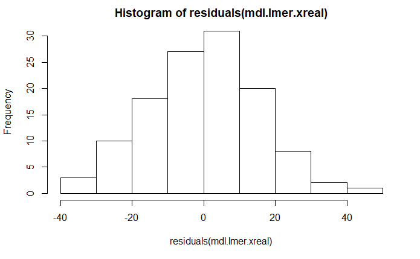

```r
hist(residuals(mdl.lmer.xreal))
```

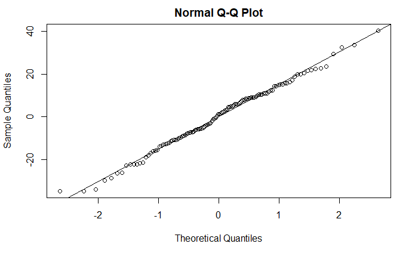

```r
qqnorm(residuals(mdl.lmer.xreal)); qqline(residuals(mdl.lmer.xreal))
```

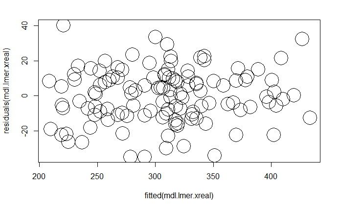

```r
plot(fitted(mdl.lmer.xreal),residuals(mdl.lmer.xreal), cex = 4)
```

## 5.4 Our second Mixed model

This second model add a by-subject random slope. Random slopes allow for the variation that exists in the random effects to be taken into account. An intercept only model provides an averaged values to our participants.

```r
mdl.lmer.xreal.2 <- lmer(dur~logFreq+(logFreq|subjects)+(1|items), data=xreal,REML=FALSE)
summary(mdl.lmer.xreal.2)
```

```
Linear mixed model fit by maximum likelihood  ['lmerMod']
Formula: dur ~ logFreq + (logFreq | subjects) + (1 | items)
   Data: xreal

     AIC      BIC   logLik deviance df.resid
  1109.5   1129.0   -547.7   1095.5      113

Scaled residuals:
    Min      1Q  Median      3Q     Max
-2.1087 -0.6068  0.0624  0.5827  2.4565

Random effects:
 Groups   Name        Variance  Std.Dev. Corr
 items    (Intercept) 5.900e+02 24.2890
 subjects (Intercept) 1.399e+03 37.4028
          logFreq     2.898e-02  0.1702  1.00
 Residual             2.829e+02 16.8195
Number of obs: 120, groups:  items, 20; subjects, 6

Fixed effects:
            Estimate Std. Error t value
(Intercept)  337.973     17.239  19.605
logFreq       -5.460      1.007  -5.423

Correlation of Fixed Effects:
        (Intr)
logFreq -0.267
```

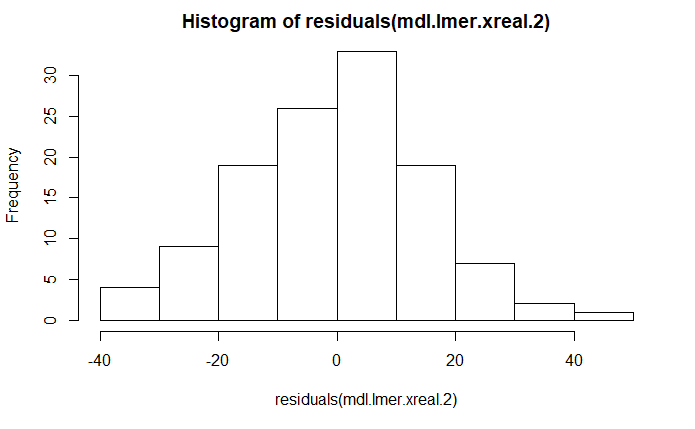

```r
hist(residuals(mdl.lmer.xreal.2))
```

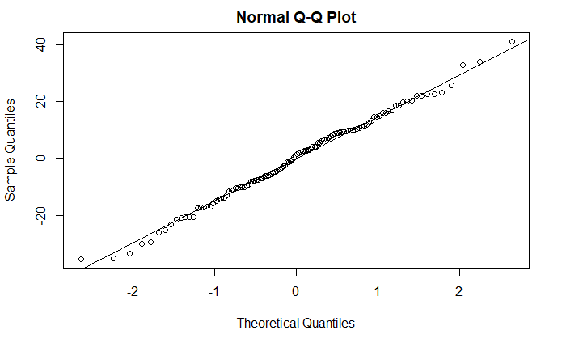

```r
qqnorm(residuals(mdl.lmer.xreal.2)); qqline(residuals(mdl.lmer.xreal.2))
```

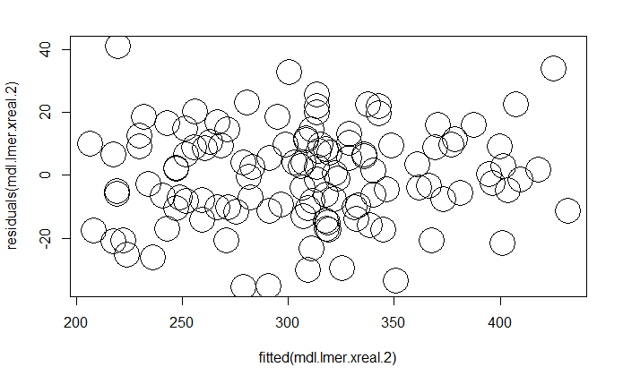

```r
plot(fitted(mdl.lmer.xreal.2),residuals(mdl.lmer.xreal.2), cex = 4)
```

## 5.5 Model comparison

But where are our p values? The lme4 developers decided not to include p values due to various issues with estimating df. What we can do instead is to compare models. We need to create a null model to allow for significance testing. As expected our predictor is significantly contributing to the difference.

```r
mdl.lmer.xreal.Null <- lmer(dur~1+(logFreq|subjects)+(1|items), data=xreal,REML=FALSE)
anova(mdl.lmer.xreal.Null,mdl.lmer.xreal.2)
```

```
Data: xreal
Models:
mdl.lmer.xreal.Null: dur ~ 1 + (logFreq | subjects) + (1 | items)
mdl.lmer.xreal.2: dur ~ logFreq + (logFreq | subjects) + (1 | items)
                    Df    AIC    BIC  logLik deviance  Chisq Chi Df Pr(>Chisq)
mdl.lmer.xreal.Null  6 1131.9 1148.6 -559.93   1119.9
mdl.lmer.xreal.2     7 1109.5 1129.0 -547.73   1095.5 24.394      1  7.852e-07

mdl.lmer.xreal.Null
mdl.lmer.xreal.2    ***
---
Signif. codes:  0 ‘***’ 0.001 ‘**’ 0.01 ‘*’ 0.05 ‘.’ 0.1 ‘ ’ 1
```

Also, do we really need random slopes? From the result below, we don’t seem to need random slopes at all, given that adding random slopes does not improve the model fit. I always recommend testing this. Most of the time I keep random slopes.

```r
anova(mdl.lmer.xreal,mdl.lmer.xreal.2)
```

```
Data: xreal
Models:
mdl.lmer.xreal: dur ~ logFreq + (1 | subjects) + (1 | items)
mdl.lmer.xreal.2: dur ~ logFreq + (logFreq | subjects) + (1 | items)
                 Df    AIC    BIC  logLik deviance  Chisq Chi Df Pr(>Chisq)
mdl.lmer.xreal    5 1105.8 1119.8 -547.92   1095.8
mdl.lmer.xreal.2  7 1109.5 1129.0 -547.73   1095.5 0.3788      2     0.8274
```

But if you are really (really!!!) obsessed by p values, then you can also use lmerTest. BUT use after comparing models to evaluate contribution of predictors

```r
library(lmerTest)
mdl.lmer.xreal.lmerTest <- lmer(dur~logFreq+(logFreq|subjects)+(1|items), data=xreal,REML=TRUE)
summary(mdl.lmer.xreal.lmerTest)
```

```
Linear mixed model fit by REML. t-tests use Satterthwaite's method [
lmerModLmerTest]
Formula: dur ~ logFreq + (logFreq | subjects) + (1 | items)
   Data: xreal

REML criterion at convergence: 1086.1

Scaled residuals:
     Min       1Q   Median       3Q      Max
-2.09692 -0.60118  0.06414  0.58479  2.46241

Random effects:
 Groups   Name        Variance  Std.Dev. Corr
 items    (Intercept) 6.294e+02 25.088
 subjects (Intercept) 1.651e+03 40.637
          logFreq     3.421e-02  0.185   1.00
 Residual             2.829e+02 16.819
Number of obs: 120, groups:  items, 20; subjects, 6

Fixed effects:
            Estimate Std. Error      df t value Pr(>|t|)
(Intercept)  337.973     18.526   7.394  18.243 2.04e-07 ***
logFreq       -5.460      1.038  18.142  -5.261 5.17e-05 ***
---
Signif. codes:  0 ‘***’ 0.001 ‘**’ 0.01 ‘*’ 0.05 ‘.’ 0.1 ‘ ’ 1

Correlation of Fixed Effects:
        (Intr)
logFreq -0.249
```

```r
detach("package:lmerTest", unload=TRUE)
```

## 5.6 Our final Mixed model

Our final model uses REML (or Restricted Maximum Likelihood Estimate of Variance Component) to estimate the model.

```r
mdl.lmer.xreal.Full <- lmer(dur~logFreq+(logFreq|subjects)+(1|items), data=xreal,REML=TRUE)
summary(mdl.lmer.xreal.Full)
```

```
Linear mixed model fit by REML ['lmerMod']
Formula: dur ~ logFreq + (logFreq | subjects) + (1 | items)
   Data: xreal

REML criterion at convergence: 1086.1

Scaled residuals:
     Min       1Q   Median       3Q      Max
-2.09692 -0.60118  0.06414  0.58479  2.46241

Random effects:
 Groups   Name        Variance  Std.Dev. Corr
 items    (Intercept) 6.294e+02 25.088
 subjects (Intercept) 1.651e+03 40.637
          logFreq     3.421e-02  0.185   1.00
 Residual             2.829e+02 16.819
Number of obs: 120, groups:  items, 20; subjects, 6

Fixed effects:
            Estimate Std. Error t value
(Intercept)  337.973     18.526  18.243
logFreq       -5.460      1.038  -5.261

Correlation of Fixed Effects:
        (Intr)
logFreq -0.249
```

```r
anova(mdl.lmer.xreal.Full)
```

```
Analysis of Variance Table
        Df Sum Sq Mean Sq F value
logFreq  1 7828.8  7828.8  27.677
```

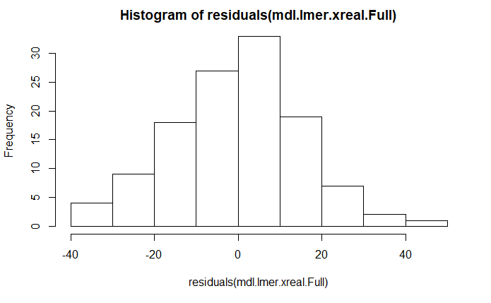

```r
hist(residuals(mdl.lmer.xreal.Full))
```

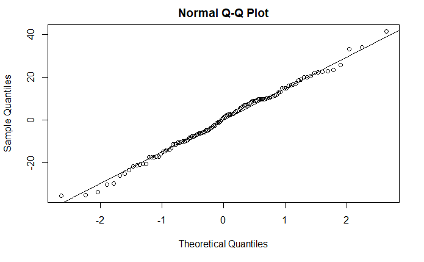

```r
qqnorm(residuals(mdl.lmer.xreal.Full)); qqline(residuals(mdl.lmer.xreal.Full))
```

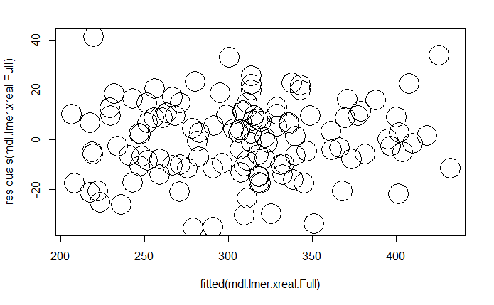

```r
plot(fitted(mdl.lmer.xreal.Full),residuals(mdl.lmer.xreal.Full), cex = 4)
```

## 5.7 Dissecting the model

```r
coef(mdl.lmer.xreal.Full)
```

```
$`items`
       (Intercept)   logFreq
Item1     352.3564 -5.460115
Item10    331.7619 -5.460115
Item11    324.7272 -5.460115
Item12    350.2316 -5.460115
Item13    353.1171 -5.460115
Item14    311.8359 -5.460115
Item15    354.0588 -5.460115
Item16    353.9386 -5.460115
Item17    288.7852 -5.460115
Item18    362.4698 -5.460115
Item19    338.1424 -5.460115
Item2     325.1858 -5.460115
Item20    359.7410 -5.460115
Item3     370.1798 -5.460115
Item4     302.4272 -5.460115
Item5     350.0497 -5.460115
Item6     338.9482 -5.460115
Item7     362.8397 -5.460115
Item8     295.5951 -5.460115
Item9     333.0694 -5.460115

$subjects
   (Intercept)   logFreq
S1    314.4695 -5.567091
S2    303.9038 -5.615180
S3    314.2921 -5.567898
S4    318.4283 -5.549073
S5    373.3005 -5.299324
S6    403.4440 -5.162127

attr(,"class")
[1] "coef.mer"
```

```r
fixef(mdl.lmer.xreal.Full)
```

```
(Intercept)     logFreq
 337.973044   -5.460115
```

```r
fixef(mdl.lmer.xreal.Full)[1]
```

```
(Intercept)
    337.973
```

```r
fixef(mdl.lmer.xreal.Full)[2]
```

```
  logFreq
-5.460115
```

```r
coef(mdl.lmer.xreal.Full)$`subjects`[1]
```

|  | (Intercept) |
| --- | --- |
| S1 | 314.4695 |
| S2 | 303.9038 |
| S3 | 314.2921 |
| S4 | 318.4283 |
| S5 | 373.3005 |
| S6 | 403.4440 |

```r
coef(mdl.lmer.xreal.Full)$`subjects`[2]
```

|  | logFreq |
| --- | --- |
| S1 | -5.567091 |
| S2 | -5.615180 |
| S3 | -5.567898 |
| S4 | -5.549073 |
| S5 | -5.299324 |
| S6 | -5.162127 |

```r
coef(mdl.lmer.xreal.Full)$`items`[1]
```

|  | (Intercept) |
| --- | --- |
| Item1 | 352.3564 |
| Item10 | 331.7619 |
| Item11 | 324.7272 |
| Item12 | 350.2316 |
| Item13 | 353.1171 |
| Item14 | 311.8359 |
| Item15 | 354.0588 |
| Item16 | 353.9386 |
| Item17 | 288.7852 |
| Item18 | 362.4698 |

[output cut: 10 more lines]

```r
coef(mdl.lmer.xreal.Full)$`items`[2]
```

|  | logFreq |
| --- | --- |
| Item1 | -5.460115 |
| Item10 | -5.460115 |
| Item11 | -5.460115 |
| Item12 | -5.460115 |
| Item13 | -5.460115 |
| Item14 | -5.460115 |
| Item15 | -5.460115 |
| Item16 | -5.460115 |
| Item17 | -5.460115 |
| Item18 | -5.460115 |

[output cut: 10 more lines]

## 5.8 Using predictions from our model

In general, I use the prediction from my final model in any plots. To generate this, we can use the following

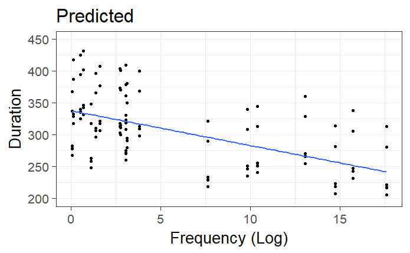

```r
xreal$Pred_Dur <- predict(lmer(dur~logFreq+(logFreq|subjects)+(1|items), data=xreal,REML=TRUE))
ggplot.xreal.Pred <- ggplot(xreal,aes(x=logFreq,y=Pred_Dur))+
                geom_point()+theme_bw(base_size = 20)+
                labs(y = "Duration", x = "Frequency (Log)",title="Predicted")+
                geom_smooth(method = lm, se=F)+coord_cartesian(ylim=c(200,450))
ggplot.xreal.Pred
```

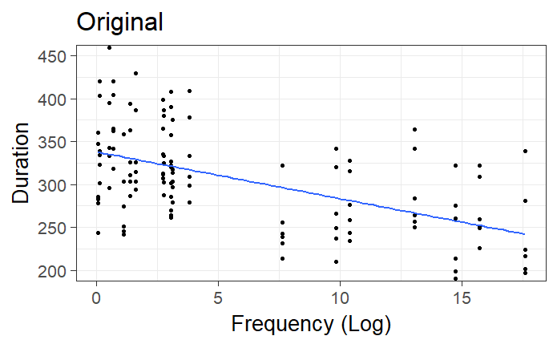

```r
## original plot
ggplot.xreal.Original <- ggplot(xreal,aes(x=logFreq,y=dur))+
                geom_point()+theme_bw(base_size = 20)+
                labs(y = "Duration", x = "Frequency (Log)",title="Original")+
                geom_smooth(method = lm, se=F)+coord_cartesian(ylim=c(200,450))
ggplot.xreal.Original
```

## 5.9 GLMM and CLMM

The code above was using a Linear Mixed Effects Modelling. The outcome was a numeric object. In some cases (as we have seen above), we may have:

1. Binary outcome (binomial)
2. Count data (poisson),
3. Multi-category outcome (multinomial)
4. Rating data (cumulative function)

The code below gives you an idea of how to specificy these models

```r
## Binomial family
## lme4::glmer(outcome~predictor(s)+(1|subject)+(1|items)..., data=data, family=binomial)
## Poisson family
## lme4::glmer(outcome~predictor(s)+(1|subject)+(1|items)..., data=data, family=poisson)
## Multinomial family
## a bit complicated as tehre is a need to use Bayesian approaches, see e.g.,
## glmmADMB
## mixcat
## MCMCglmm
## see https://gist.github.com/casallas/8263818
## Rating data, use following
## ordinal::clmm(outcome~predictor(s)+(1|subject)+(1|items)..., data=data)
## Remember to test for random effects and whether slopes are needed.
```

# 6 Running your code and automatically drawing quality tables for publications

See this website for how to run and automatically draw tables for your publications. I haven’t tested this but it is in development: 7) https://www.r-bloggers.com/elegant-regression-results-tables-and-plots-in-r-the-finalfit-package/amp